# Assignment 8 - Plotting amounts, proportions, and using color

Luke Henslee

2021-03-31

### Task 1: Heat maps

#### 1) Import data and subset 1950 – 2017 observations

```r
npgo.pdo <- read.csv("npgo-pdo.csv")

npgo.pdo.sub <- npgo.pdo %>%
  filter(npgo.pdo$Year < 2018)

# Turn months into factors and set levels to the R constant 'month.abb'
npgo.pdo.sub$Mon <- factor(npgo.pdo.sub$Mon, levels = month.abb)
```

#### 2) NPGO by month and year

To visualize fluxuations in NPGO by month and year, we will create a heatmap which uses the ‘viridis’ color palette, which is common for visualizing continuous variables.

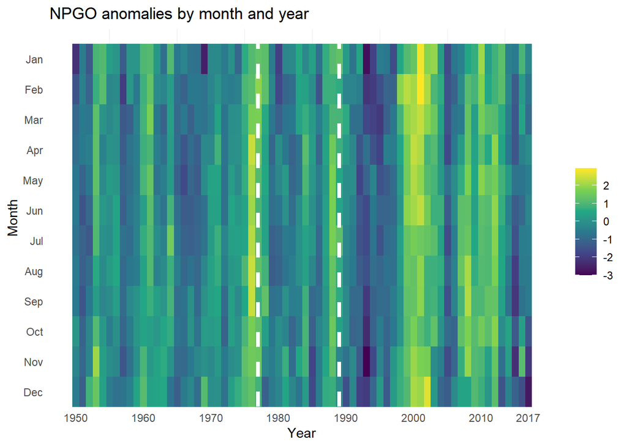

```r
ggplot(data = npgo.pdo.sub, aes(x = Year, y = Mon)) +
  geom_raster(aes(fill = NPGO)) +
  scale_y_discrete(limits = sort(npgo.pdo.sub$Mon, decreasing = TRUE)) +
  scale_x_continuous(breaks = c(1950, 1960, 1970, 1980, 1990, 2000, 2010, 2017)) +
  scale_fill_viridis_c(name = NULL) +
  theme_minimal() +
  theme(panel.grid.major = element_blank()) +
  labs(title = "NPGO anomalies by month and year", x = "Year", y = "Month") +
  geom_vline(xintercept = 1977, color = "white", linetype = "dashed", size = 1.5) +
  geom_vline(xintercept = 1989, color = "white", linetype = "dashed", size = 1.5)
```

#### 3) PDO by month and year

This time we are going to try an unconventional color pallete from the ‘wesanderson’ package.

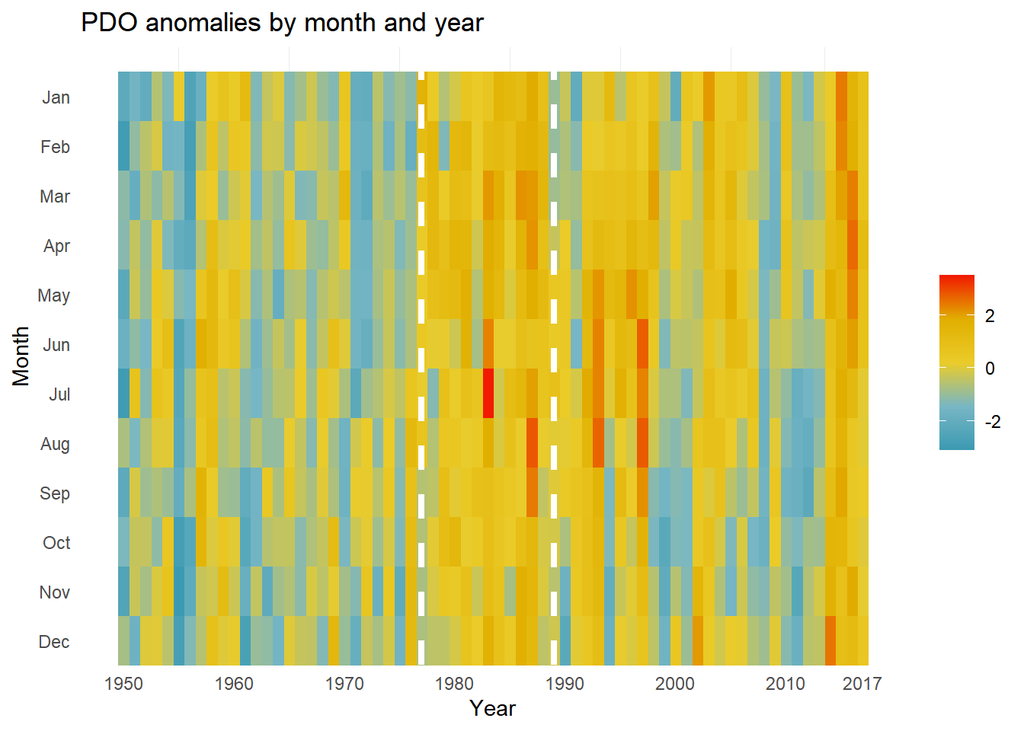

```r
library(wesanderson)

ggplot(data = npgo.pdo.sub, aes(x = Year, y = Mon)) +
  geom_raster(aes(fill = PDO)) +
  scale_y_discrete(limits = sort(npgo.pdo.sub$Mon, decreasing = TRUE)) +
  scale_x_continuous(breaks = c(1950, 1960, 1970, 1980, 1990, 2000, 2010, 2017)) +
  scale_fill_gradientn(colors = wes_palette("Zissou1", 100, type = "continuous"), name = NULL)+
  theme_minimal() +
  theme(panel.grid.major = element_blank()) +
  labs(title = "PDO anomalies by month and year", x = "Year", y = "Month")+
  geom_vline(xintercept = 1977, color = "white", linetype = "dashed", size = 1.5) +
  geom_vline(xintercept = 1989, color = "white", linetype = "dashed", size = 1.5)
```

It’s a little headachey, but kind of interesting…. It actually does a pretty good job of showing the values near the mean and those that are extreme anamolies in either direction.

#### 4) Visually depict a relationship between NPGO and PDO by month and year

To show a possible relationship between NPGO and PDO I’m going to plot the absolute values of the differences between the two by month and year. Cells which have values near zero indicate that PDO and NPGO fluctuated together. A plot of mostly the same color should indicate a strong relationship between NPGO and PDO.

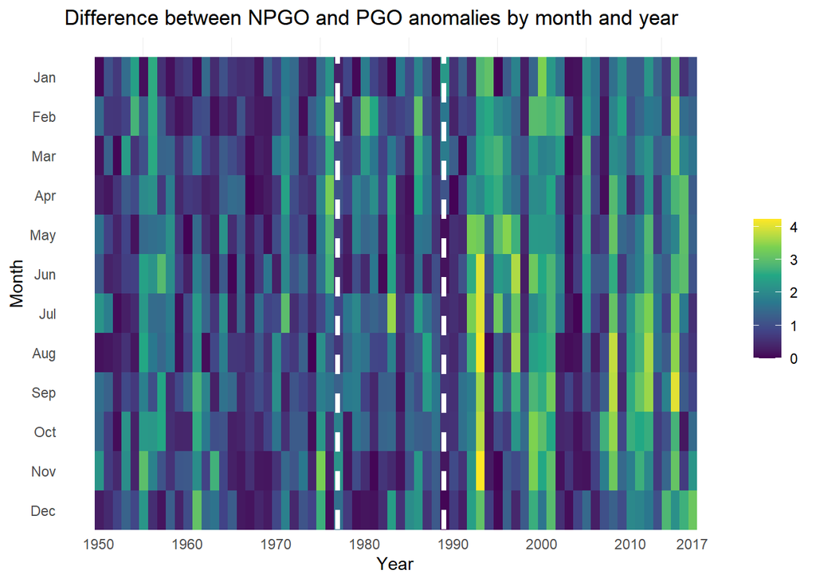

```r
# Create new variable 'abs.diff'
npgo.pdo.sub$abs.diff <- abs(npgo.pdo.sub$NPGO - npgo.pdo.sub$PDO)

ggplot(data = npgo.pdo.sub, aes(x = Year, y = Mon)) +
  geom_raster(aes(fill = abs.diff)) +
  scale_y_discrete(limits = sort(npgo.pdo.sub$Mon, decreasing = TRUE)) +
  scale_x_continuous(breaks = c(1950, 1960, 1970, 1980, 1990, 2000, 2010, 2017)) +
  scale_fill_viridis_c(name = NULL) +
  theme_minimal() +
  theme(panel.grid.major = element_blank()) +
  labs(title = "Difference between NPGO and PGO anomalies by month and year", x = "Year", y = "Month") +
  geom_vline(xintercept = 1977, color = "white", linetype = "dashed", size = 1.5) +
  geom_vline(xintercept = 1989, color = "white", linetype = "dashed", size = 1.5)
```

Okay, not bad. I’m going to simplify things by assigning a ‘0’ to negative anomalies and ‘1’ to positive anomolies. Then I will plot the difference between NPGO and PDO. Months which have the same directionality of their anomalies will add up to zero and months with different directionality will add up to one. There will only be two colors in this heat map.

```r
dir.npgo <- vector(length = nrow(npgo.pdo.sub))

for(i in 1:length(dir.npgo)){
  if(npgo.pdo.sub[i,3] > 0) {
    dir.npgo[i] = 1
  } else {
    dir.npgo[i] = 0
  }
}

dir.pdo <- vector(length = nrow(npgo.pdo.sub))

for(i in 1:length(dir.pdo)){
  if(npgo.pdo.sub[i,4] > 0) {
    dir.pdo[i] = 1
  } else {
    dir.pdo[i] = 0
  }
}

npgo.pdo.sub$dir <- factor(abs(dir.npgo - dir.pdo))
```

Okay, now let’s make the plot.

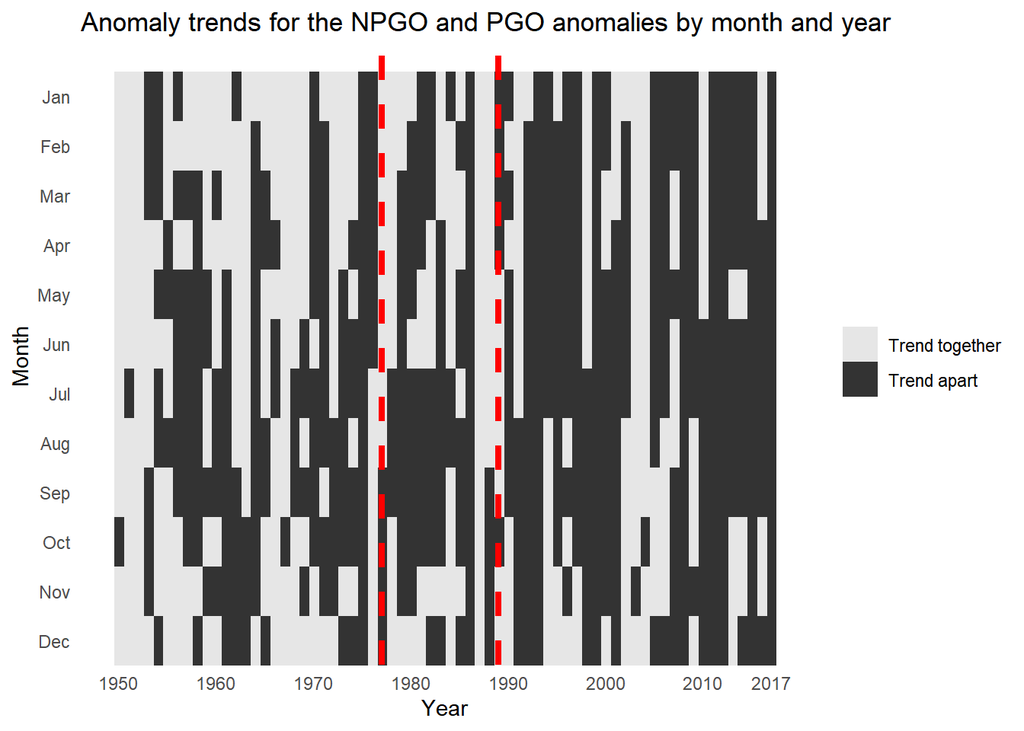

```r
ggplot(data = npgo.pdo.sub, aes(x = Year, y = Mon)) +
  geom_raster(aes(fill = dir)) +
  scale_y_discrete(limits = sort(npgo.pdo.sub$Mon, decreasing = TRUE)) +
  scale_x_continuous(breaks = c(1950, 1960, 1970, 1980, 1990, 2000, 2010, 2017)) +
  scale_fill_grey(start = 0.9, end = 0.2, name = NULL, labels = c("Trend together", "Trend apart")) +
  theme_minimal() +
  theme(panel.grid.major = element_blank(), panel.grid.minor = element_blank()) +
  labs(title = "Anomaly trends for the NPGO and PGO anomalies by month and year", x = "Year", y = "Month") +
  geom_vline(xintercept = 1977, color = "red", linetype = "dashed", size = 1.5) +
  geom_vline(xintercept = 1989, color = "red", linetype = "dashed", size = 1.5)
```

I kind of like it! I don’t know if it qualifies as a heatmap, but it does show us some interesting visuals about the relationship between the two indicies.

### Task 2: Plotting multiple proportions

#### 1) Import data

```r
narw <- read.csv("NARW_mort.csv", fileEncoding="UTF-8-BOM")
```

Have to include the ‘fileEncoding = “UTF-8_BOM”’, otherwise there are strange symbols in the column heads. I’ve run into this problem before when the .csv file was uploaded from a MAC.

#### 2) Create mosiac plot

First I would like to create a mosaic plot that will show proportions of sex, country, and cause of death for Northern Atalantic Right Wales.

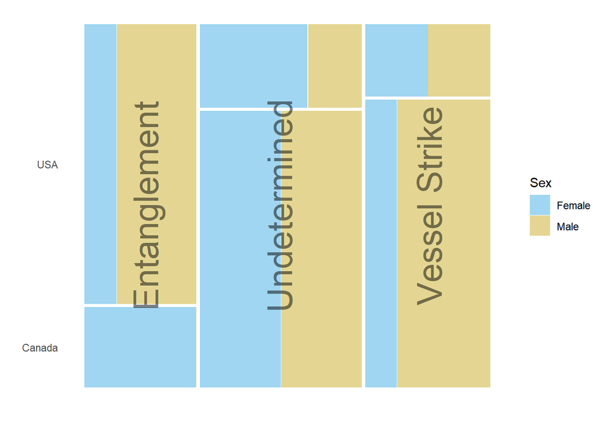

```r
library(ggmosaic)

ggplot(data = narw) +
  geom_mosaic(aes(x = product(Country, CauseDeath), fill = Sex)) +
  scale_fill_manual(values = c("#88CCEE", "#DDCC77"), labels = c("Female", "Male")) +
  annotate("text", x = .15, y = .5, label = "Entanglement", angle = 90, size = 10, alpha = .5) +
    annotate("text", x = .48, y = .5, label = "Undetermined", angle = 90, size = 10, alpha = .5) +
  annotate("text", x = .85, y = .5, label = "Vessel Strike", angle = 90, size = 10, alpha = .5) +
  labs(y = "", x = "") +
  theme_minimal() +
  theme(panel.grid.major = element_blank()) +
  theme(axis.text.x = element_blank(), axis.ticks = element_blank())
```

I think it looks pretty good. It gives us a good idea of mortality proportions, but unfortunately this doesn’t show us the year of the data. I’m going to attempt to create a treemap a la Wilke, let’s see how it does.

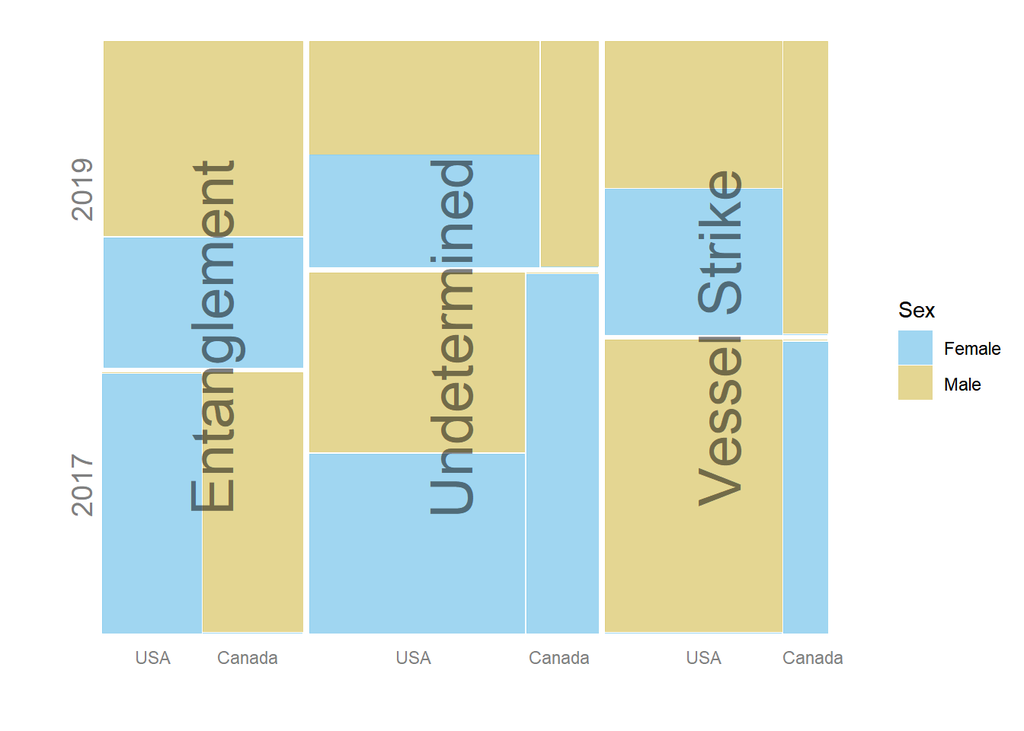

```r
ggplot(data = narw) +
  geom_mosaic(aes(x = product(Country, Year, CauseDeath), fill = Sex)) +
  scale_fill_manual(values = c("#88CCEE", "#DDCC77"), labels = c("Female", "Male")) +
  annotate("text", x = .15, y = .5, label = "Entanglement", angle = 90, size = 10, alpha = .5) +
    annotate("text", x = .48, y = .5, label = "Undetermined", angle = 90, size = 10, alpha = .5) +
  annotate("text", x = .85, y = .5, label = "Vessel Strike", angle = 90, size = 10, alpha = .5) +
  annotate("text", x = -.03, y = .25, label = "2017", angle = 90, size = 5, alpha = .5) +
  annotate("text", x = -.03, y = .75, label = "2019", angle = 90, size = 5, alpha = .5) +
  annotate("text", x = .07, y = -.04, label = "USA", size = 3,  alpha = .5) +
  annotate("text", x = .2, y = -.04, label = "Canada", size = 3,  alpha = .5) +
  annotate("text", x = .43,  y = -.04, label = "USA", size = 3,  alpha = .5) +
  annotate("text", x = .63, y = -.04, label = "Canada", size = 3,  alpha = .5) +
  annotate("text", x = .83,  y = -.04, label = "USA", size = 3,  alpha = .5) +
  annotate("text", x = .98, y = -.04, label = "Canada", size = 3,  alpha = .5) +
  labs(x = "", y = "") +
  theme_minimal() +
  theme(axis.text.x = element_blank(), axis.text.y = element_blank(), panel.grid.major = element_blank())
```

Eh, we fit all the varibles in, but what a pain to have to manually place each of our labels. I know there is a better way and I actually looked up Wilke’s source code for his treemaps on github, turns out there is a package called ‘treemapify’.

#### 3) Create treemap

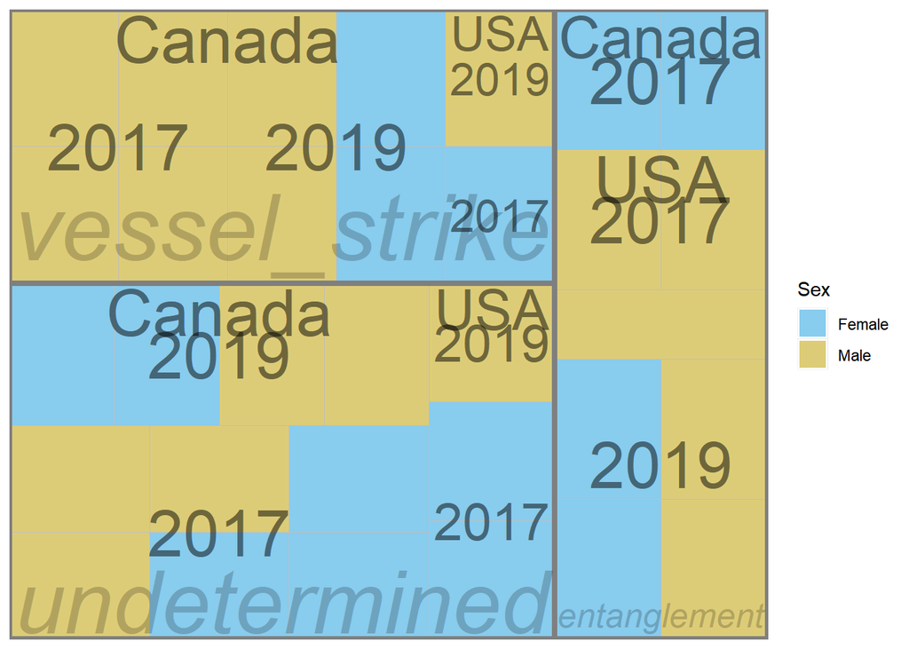

```r
library(treemapify)

# Have to create a new variable called "count", which geom_treemap requires for the 'area' argument.
narw$count <- 1

ggplot(narw, aes(area = count, fill = Sex,
                subgroup = CauseDeath, subgroup2 = Country, subgroup3 = Year, label = "")) +
  geom_treemap() +
  geom_treemap_subgroup_border() +
  geom_treemap_subgroup_text(place = "bottom", grow = T, alpha = 0.2, colour =
                             "black", fontface = "italic") +
  geom_treemap_text(colour = "white", place = "top") +
  geom_treemap_subgroup2_text(place = "top", grow = F, alpha = 0.5, colour =
                             "black") +
  geom_treemap_subgroup3_text(place = "centre", grow = F, alpha = 0.5, colour =
                             "black", ) +
  scale_fill_manual(values = c("#88CCEE", "#DDCC77"), labels = c("Female", "Male"), name = "Sex")
```

So, the area argument uses a numeric variable, so if our data had a count of each cause of death, of each sex, in each country, in each year, then we would change the shape of the rectangle. In this method, there is just a tile for each observation, so it serves the same purpose but the shape isn’t a rectangle its some kind of tetris shape. This plot is functional, but yeah, a little brain-achey.

Next I’m going to create small multiples to try to show all four variables in the dataset.

#### 4) Create small multiples

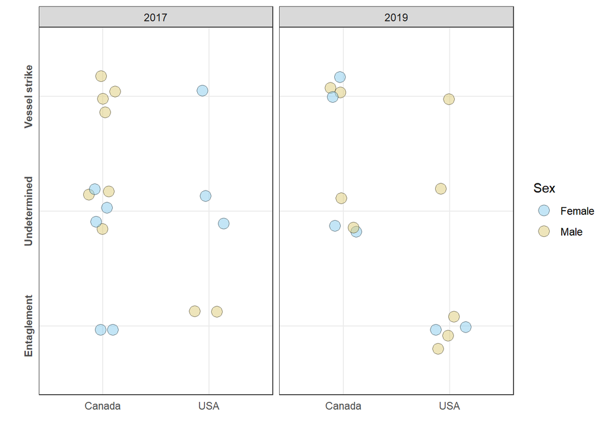

```r
ggplot(narw, aes(x = Country, y = CauseDeath, fill = Sex)) +
  geom_point(shape=21, position = position_jitter(w = .15, h = .2), size = 4, alpha = .5) +
  scale_fill_manual(values = c("#88CCEE", "#DDCC77"), labels = c("Female", "Male")) +
  facet_wrap(narw$Year, ncol = 2) +
  labs(y = "", x = "") +
  theme_bw() +
  scale_y_discrete(labels = c("Entaglement", "Undetermined", "Vessel strike")) +
  theme(axis.text.y = element_text(face = "bold", angle = 90, hjust = .5), axis.ticks = element_blank())
```

This shows us all of the information in our dataset, but I think a table would do this job better. I’m starting to realize how in-depth these plots can be.

#### 5) Conclusions

Especially after looking at Wilke’s source code for his plots, I’m realizing that codes can be hundreds of lines for a single plot. I know R is good for customizing every little thing in your plot, but sometimes it seems like Excel would be easier. I feel like I learned a lot however, and utilized new packages such as “ggmosaic” and “treemapify”.